# hw01_2021_12659

## Problem 3

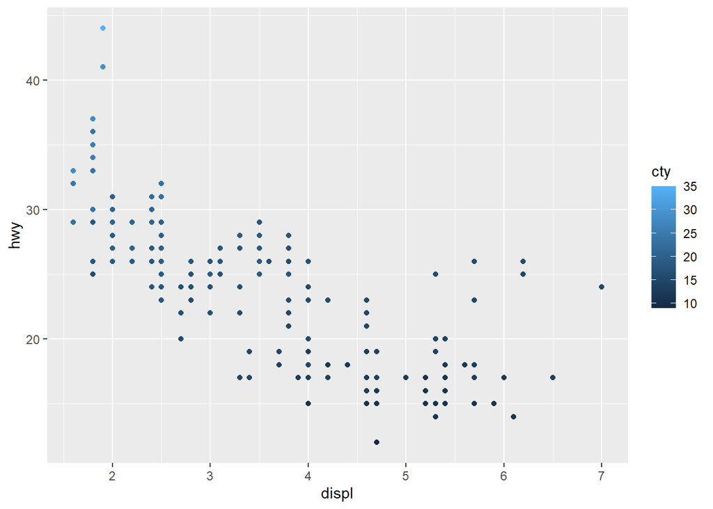

```r
# map a continous variable to color
ggplot(data = mpg) +
  geom_point(mapping = aes(x = displ, y = hwy, colour = cty))
```

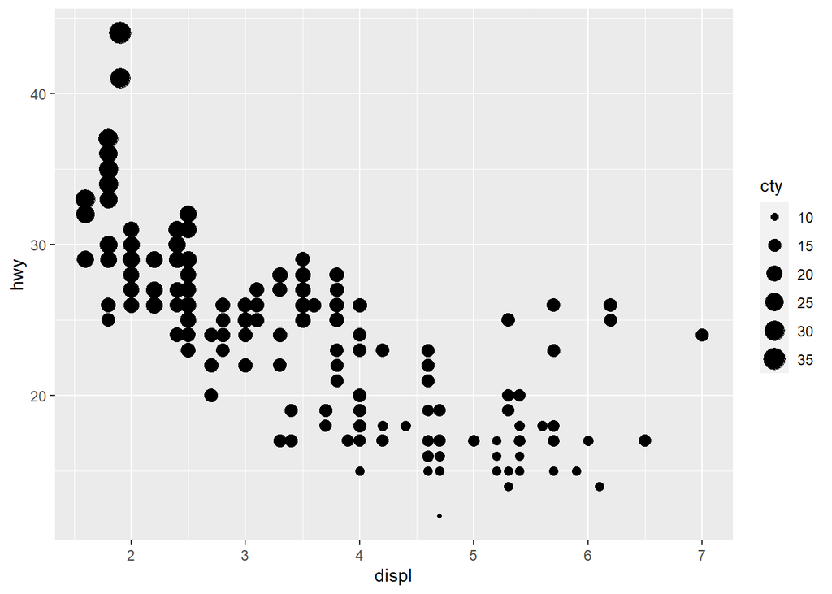

```r
# map a continous variable to size
ggplot(data = mpg) +
  geom_point(mapping = aes(x = displ, y = hwy, size = cty))
```

```r
# map a continous variable to shape
# error
# ggplot(data = mpg) + geom_point(mapping = aes(x = displ, y = hwy, shape = cty))
```

An error message prints when trying to map the continuous variables to shape.

In the case of categorical variables, color, size, and shape are represented according to each variable value. On the other hand, in the case of a continuous function, a range is automatically set. And color and size are displayed according to the range and shape cannot be mapped to a continuous variable.

# Textbook 3.5.1

## Problem 2

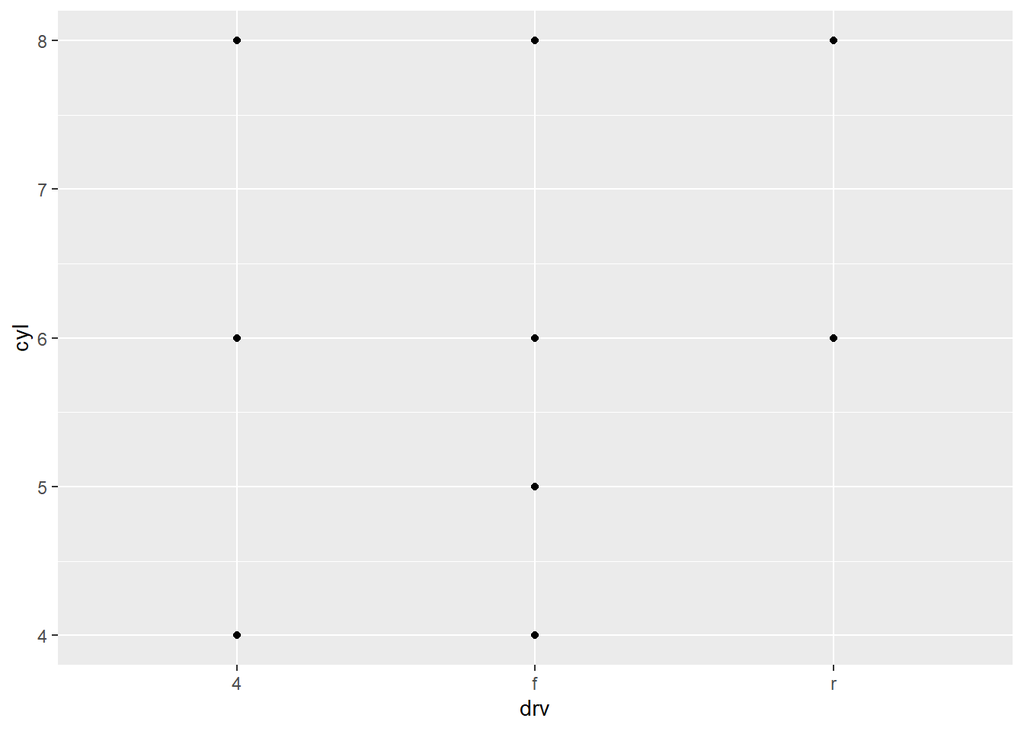

```r
ggplot(data = mpg) +
  geom_point(mapping = aes(x = drv, y = cyl))
```

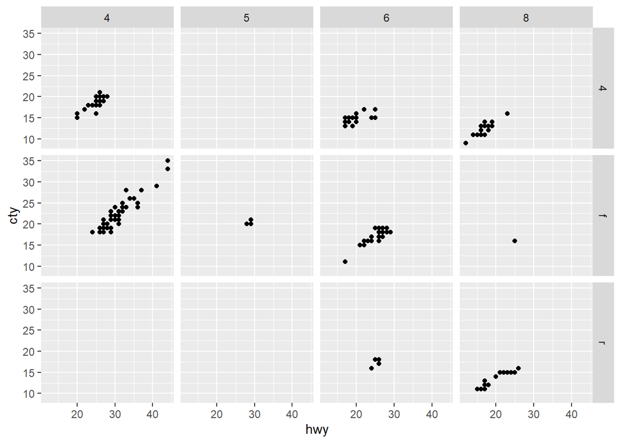

```r
ggplot(data = mpg) +
  geom_point(mapping = aes(x = hwy, y = cty)) +
  facet_grid(drv ~ cyl)
```

In facets, an empty cell is the part where there are no observations of drv and cyl. These are the same as the spotless parts of the scatterplot of drv and cyl.